# practical_exercise_2, Methods 3, 2021, autumn semester

Caroline Hommel

29th of September 2021

# Assignment 1: Using mixed effects modelling to model hierarchical data

In this assignment we will be investigating the *politeness* dataset of Winter and Grawunder (2012) and apply basic methods of multilevel modelling.

```r
politeness <- read.csv('politeness.csv') ## read in data
```

# Exercise 1 - describing the dataset and making some initial plots

##1) Describe the dataset, such that someone who happened upon this dataset could understand the variables and what they contain

*Subject* The first letter indicates whether it’s a male or female (f or m) and the number indicates which number participant it is.

*Gender* gender of the participant. F for female and m for male.

*Scenario* The participants have been asked to behave within different scenarios -7 different e.g. asking for a favor or taking orders.

*Attitude* Whether it’s formal or informal in a condition

*Total duration* For how long the participants are talking

*f0mm* Frequency in hertz

*his_count* The amount of noisy breath intakes during the response.

###i. Also consider whether any of the variables in *politeness* should be encoded as factors or have the factor encoding removed. Hint: `?factor`

```r
#Changed all characters to factors in one line
politeness[sapply(politeness, is.character)] <- lapply(politeness[sapply(politeness, is.character)], as.factor)

#Changing scenario from integer to factor
politeness$scenario <- as.integer(politeness$scenario)
```

##2) Create a new data frame that just contains the subject *F1* and run two linear models; one that expresses *f0mn* as dependent on *scenario* as an integer; and one that expresses *f0mn* as dependent on *scenario* encoded as a factor

```r
#creating a data frame only with data from subject F1
f1data <- politeness %>%
  filter(subject == "F1")

model <- lm(f0mn~scenario, data = f1data)

f1data$scenario <- as.factor(f1data$scenario)
model2 <- lm(f0mn~scenario, data = f1data)
```

###i. Include the model matrices, $X$ from the General Linear Model, for these two models in your report and describe the different interpretations of *scenario* that these entail

```r
#creating design matrices
model.matrix(model)
```

```
##    (Intercept) scenario
## 1            1        1
## 2            1        1
## 3            1        2
## 4            1        2
## 5            1        3
## 6            1        3
## 7            1        4
## 8            1        4
## 9            1        5
## 10           1        5
## 11           1        6
## 12           1        6
## 13           1        7
## 14           1        7
## attr(,"assign")
## [1] 0 1
```

```r
model.matrix(model2)
```

```
##    (Intercept) scenario2 scenario3 scenario4 scenario5 scenario6 scenario7
## 1            1         0         0         0         0         0         0
## 2            1         0         0         0         0         0         0
## 3            1         1         0         0         0         0         0
## 4            1         1         0         0         0         0         0
## 5            1         0         1         0         0         0         0
## 6            1         0         1         0         0         0         0
## 7            1         0         0         1         0         0         0
## 8            1         0         0         1         0         0         0
## 9            1         0         0         0         1         0         0
## 10           1         0         0         0         1         0         0
## 11           1         0         0         0         0         1         0
## 12           1         0         0         0         0         1         0
## 13           1         0         0         0         0         0         1
## 14           1         0         0         0         0         0         1
## attr(,"assign")
## [1] 0 1 1 1 1 1 1
## attr(,"contrasts")
## attr(,"contrasts")$scenario
## [1] "contr.treatment"
```

###ii. Which coding of *scenario*, as a factor or not, is more fitting? Since the scenarios are nominal and cannot be ‘compared’ to each other, since e.g. scenario 1 is not double as much anything as scenario 2. We need to create two matrices, because the first one doesn’t show that all scenarios need to ‘weigh’ as much as each other.

##3) Make a plot that includes a subplot for each subject that has *scenario* on the x-axis and *f0mn* on the y-axis and where points are colour coded according to *attitude*

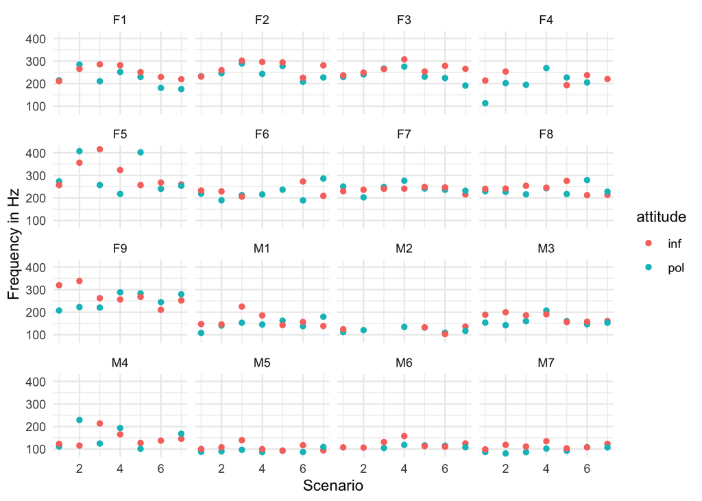

```r
#making a plot of all the subjects
ggplot(politeness, aes(x=scenario, y=f0mn, color = attitude))+
  geom_point()+
#like random intercept -each subject will get their own little plot
  facet_wrap(~subject)+
  theme_minimal()+
  ylab("Frequency in Hz")+
  xlab("Scenario")
```

###i. Describe the differences between subjects All the M’s have lower frequency, which makes sense since it’s the plot of the mens voices.It looks like the effect of attitude is larger on some subjects than other.For the men their is almost no difference between informal and polite.

# Exercise 2 - comparison of models

```r
example.formula <- formula(dep.variable ~ first.level.variable + (1 | second.level.variable))
```

##1) Build four models and do some comparisons i. a single level model that models *f0mn* as dependent on *gender*

```r
single <- lm(f0mn ~gender, data = politeness)
```

###ii. a two-level model that adds a second level on top of i. where unique intercepts are modelled for each *scenario*

```r
twolevel <- lmer(f0mn ~ gender + (1 | scenario), data = politeness)
```

###iii. a two-level model that only has *subject* as an intercept

```r
twolevel2 <- lmer(f0mn ~ gender + (1 | subject), data = politeness)
```

###iv. a two-level model that models intercepts for both *scenario* and *subject*

```r
twolevel3 <- lmer(f0mn ~ gender + (1 | subject) + (1 | scenario), data = politeness)
```

###v. which of the models has the lowest residual standard deviation, also compare the Akaike Information Criterion `AIC`?

```r
AIC(single, twolevel, twolevel2, twolevel3)
```

|  | df | AIC |
| --- | --- | --- |
| single | 3 | 2163.971 |
| twolevel | 4 | 2152.314 |
| twolevel2 | 4 | 2099.626 |
| twolevel3 | 5 | 2092.482 |

```r
tabel <- c('single', 'twolevel', 'twolevel2', 'twolevel3')

#from lme4 -extracting residual standard deviation
sigma <- c(sigma(single), sigma(twolevel), sigma(twolevel2), sigma(twolevel3))

as_tibble(rbind(tabel, sigma))
```

| V1 | V2 | V3 | V4 |
| --- | --- | --- | --- |
| single | twolevel | twolevel2 | twolevel3 |
| 39.4626791688879 | 38.4480006729009 | 32.0428716618224 | 30.6580347795662 |

```r
#(or data.frame(rbind(tabel, sigma))
```

The two-level model that models intercepts for both *scenario* and *subject* has the lowest AIC (2092) and the lowest residual standard deviation (30.65).

###vi. which of the second-level effects explains the most variance? The model with *subject* as the second level effect (random intercept) explains the variance the better than the model with *scenario* as the second level effect.

##2) Why is our single-level model bad? The model doesn’t take individual differences in pitch into account.

###i. create a new data frame that has three variables, *subject*, *gender* and *f0mn*, where *f0mn* is the average of all responses of each subject, i.e. averaging across *attitude* and *scenario*

```r
#na.omit removes all na'values' from the data set
new_df <- politeness %>%
  na.omit %>%
  group_by(subject, gender) %>%
  summarise(avg_f0mn=(mean(f0mn)))
```

###ii. build a single-level model that models *f0mn* as dependent on *gender* using this new data set

```r
new_single <- lm(avg_f0mn~gender, data=new_df)
```

###iii. make Quantile-Quantile plots, comparing theoretical quantiles to the sample quantiles using `qqnorm` and `qqline` for the new single-level model and compare it to the old single-level model (from 1).i).

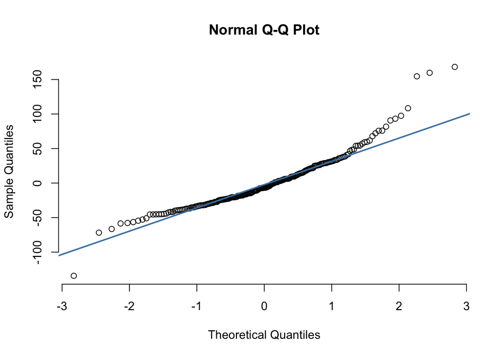

```r
qqnorm(resid(single), pch = 1, frame = FALSE)
qqline(resid(single), col = "steelblue", lwd = 2)
```

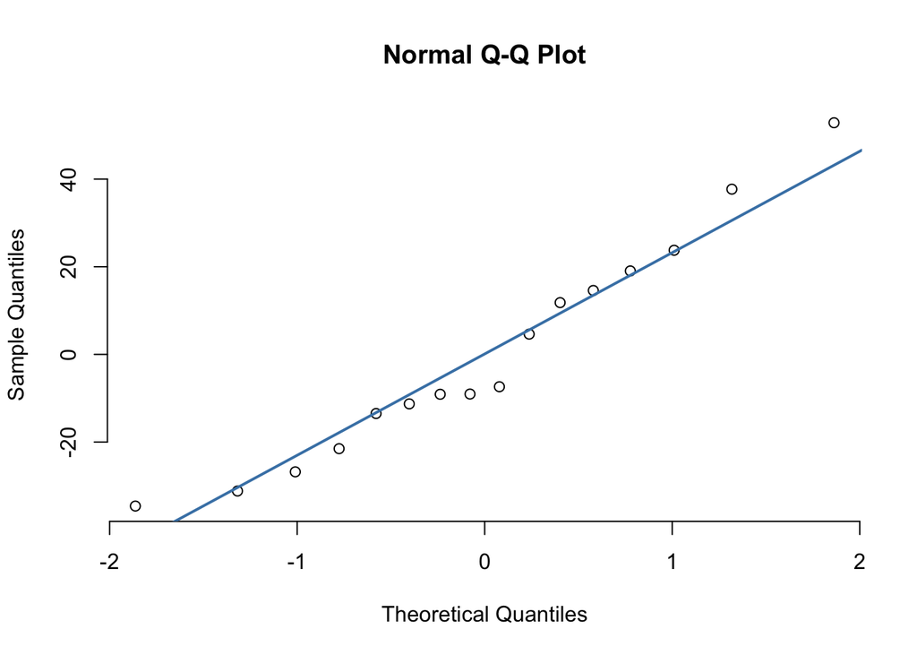

```r
qqnorm(resid(new_single),pch = 1, frame = FALSE)
qqline(resid(new_single), col = "steelblue", lwd = 2)
```

Which model’s residuals ($\epsilon$) fulfill the assumptions of the General Linear Model better? It looks like plot number two with the averaged frequency pr. participant (with the fewest data points) is more linear and the data points look more equally distributed on each side of the blue line. The first model looks more systematically distributed and the data points are not as equally distributed on each sides of the blue line.

###iv. Also make a quantile-quantile plot for the residuals of the multilevel model with two intercepts. Does it look alright?

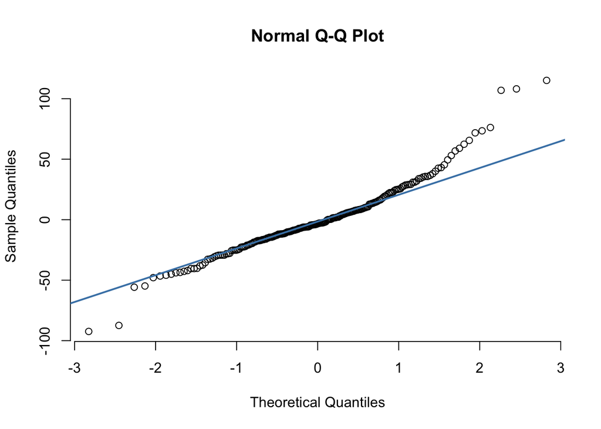

```r
qqnorm(resid(twolevel3),pch = 1, frame = FALSE)
qqline(resid(twolevel3), col = "steelblue", lwd = 2)
```

It is a little better than the others, since there is still some deviation from the line in the outer quantiles, but all along the middle the data points follows the blue line quite well.

##3) Plotting the two-intercepts model ###i. Create a plot for each subject, (similar to part 3 in Exercise 1), this time also indicating the fitted value for each of the subjects for each for the scenarios (hint use `fixef` to get the “grand effects” for each gender and `ranef` to get the subject- and scenario-specific effects)

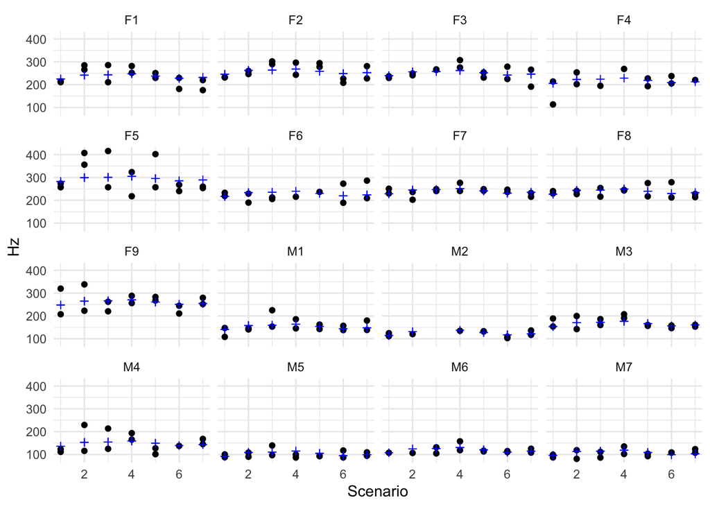

```r
library("lme4")
data(package = "lme4")

politeness <- politeness %>% na.omit(politeness)
#new column with the predicted y-values
politeness$yhat <- predict(twolevel3)

ggplot(politeness, aes(x = scenario, y = f0mn))+
  geom_point() +
  geom_point(aes(x = scenario, y = yhat), col = "blue", shape = 3) +
  facet_wrap(~ subject)+
  xlab('Scenario') +
  ylab('Hz') +
  theme_minimal()
```

Blue = predicted and black = the actual observed values.

# Exercise 3 - now with attitude

##1) Carry on with the model with the two unique intercepts fitted ( *scenario* and *subject*). i. now build a model that has *attitude* as a main effect besides *gender*

```r
doubble_model <- lmer(f0mn ~ gender + attitude + (1 | subject) + (1 | scenario), data = politeness)
```

###ii. make a separate model that besides the main effects of *attitude* and *gender* also include their interaction

```r
interaction_model <- lmer(f0mn ~ attitude*gender + (1 | subject) + (1 | scenario), data = politeness)
```

###iii. describe what the interaction term in the model says about Korean males pitch when they are polite relative to Korean women’s pitch when they are polite (you don’t have to judge whether it is interesting)

How much the effects of attitude polite changes when it goes from female to male woman’s frequency is influenced more by the change of attitude than male’s frequency. But since the error bars overlap the mean frequency could possible lay within this error bar and therefore there is a uncertainty according to if there is an effect.

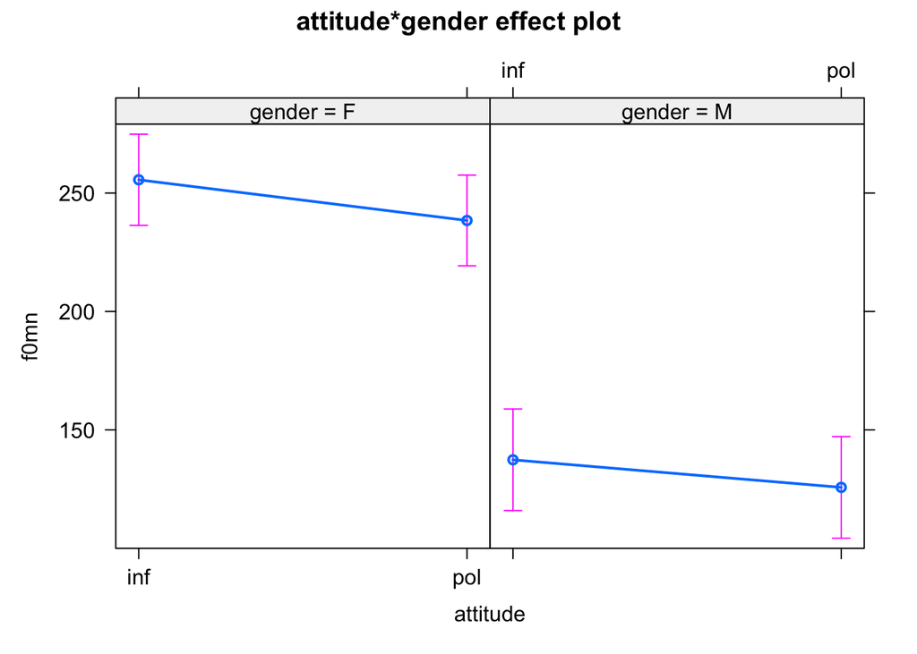

```r
plot(effects::allEffects(interaction_model))
```

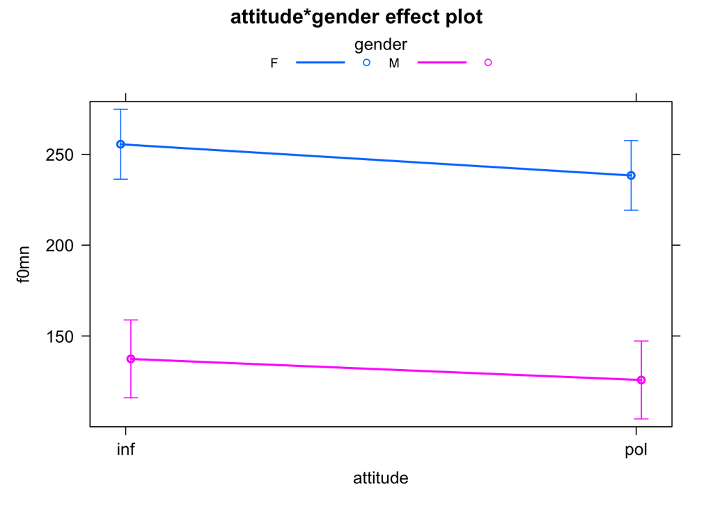

```r
plot(allEffects(interaction_model), multiline=TRUE, ci.style="bars")
```

##2) Compare the three models (1. gender as a main effect; 2. gender and attitude as main effects; 3. gender and attitude as main effects and the interaction between them. For all three models model unique intercepts for *subject* and *scenario*) using residual variance, residual standard deviation and AIC.

```r
AIC <-AIC(twolevel3, doubble_model, interaction_model)

#to be able to add the names into a scheme
tabel2 <- c('twolevel3', 'doubble_model', 'interaction_model')

#from lme4 -extracting residual standard deviation
sigma2 <- c(sigma(twolevel3), sigma(doubble_model), sigma(interaction_model))

#residual variance
variances <- c(var(resid(twolevel3)), var(resid(doubble_model)),var(resid(interaction_model)))

#collecting them all in one scheme
as.tibble(cbind(tabel2, sigma2, AIC, variances))
```

| tabel2 | sigma2 | df | AIC | variances |
| --- | --- | --- | --- | --- |
| twolevel3 | 30.65803 | 5 | 2092.482 | 859.6798 |
| doubble_model | 29.71087 | 6 | 2077.131 | 802.1478 |
| interaction_model | 29.75684 | 7 | 2072.618 | 800.4911 |

The model with gender as the main effect has the highest value in all three methods of comparison.

##3) Choose the model that you think describe the data the best - and write a short report on the main findings based on this model.

The data set consists of frequency measurements of 7 men and 9 women. Their voice frequency was measured over 7 different scenarios, in two different attitudes - polite and informal. This means all participants went through 14 trials in total (except for a few missing values). Other variables include gender, hiss count and total duration of the specific trial.

After running different models on the data, the following model was chosen to investigate the effect of gender and attitude on pitch.

frequency ~ gender + attitude + (1 | subject) + (1 | scenario)

The dependent variable is the pitch frequency, the fixed effects include gender and attitude and subject and scenario are modelled as random intercepts. Since humans naturally have different pitch frequencies, and what we are interested in is how it is changed under certain circumstances, it is relevant to include random intercepts for each subject. If it was not included, the model would not take into account the repeated measurement design of the experiment. Furthermore, if you do not include random intercepts, you would overlook a very clear underlying effect in the data, thus having the risk of not interpreting the model properly. Therefore, including random intercepts for subject and scenario was found important.

This model was chosen since compared to a model with only gender as a fixed effect (and random intercepts for subject and scenario), the chosen model explained more variance. A more complex model including the interaction between gender and attitude could have been chosen, but using the *anova* function we found the interaction to be insignificant. Thus a simpler model was preferred.

After building the model a quantile-quantile plot of the chosen model was made testing for the assumption of normality of the residuals.

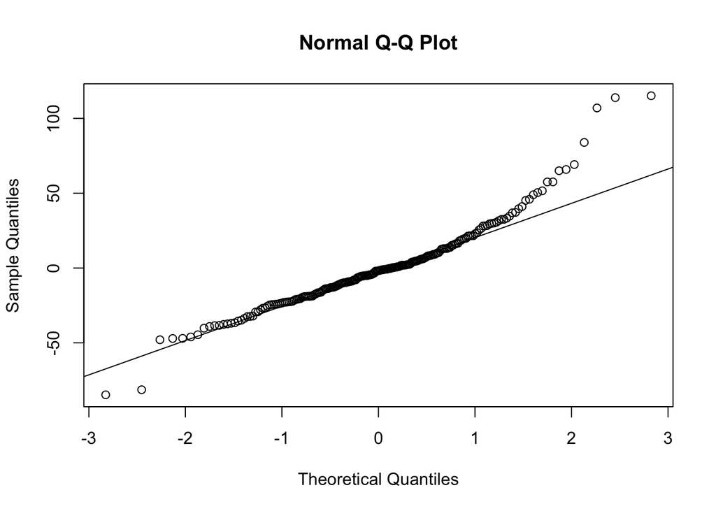

```r
qqnorm(resid(doubble_model))
qqline(resid(doubble_model))
```

Figure 1. Quantile Quantile plot for the residuals of the multilevel model.

By checking the plot, it was concluded that the model fulfilled the assumption, since most of the points are on the straight line, and we only see a small pattern of deviation at the end of the line.

Investigating the coefficients, it was found that our intercept was 254.4, showing the average of the women’s pitch frequency in the informal condition. Gender significantly predicts frequency (β = -115.14, p< .001). Additionally, it was found that attitude significantly predicts frequency (β = -14.82, p< .001). This means that males generally have a lower frequency compared to women, and that changing attitude from informal to polite tends to result in a lower frequency when the other variables are held constant.

We see that there is a higher variance (585.6) and std. dev. (24.20) for the second level effect subject compared to the second level effect of scenario where variance (106.7) and std. dev. (10.33) which means that there is a higher variability within *subjects* compared to *scenarios*.

The special thing shown by our model is that both Korean men and womens frequency gets lower in polite scenarios compared to informal scenarios, whereas in many other languages it is the opposite, when in polite scenarios the pitch gets higher for both men and women (Winter, 2013) ergo there are also cultural differences.

This is written in collaboration with all of study group four.